# Trabajo Final Python - Modulo 1-Richard Douglas

### Ejercicio 1 - Python

**Programa de MÁSTER EN DATA SCIENCE =Y BUSINESS ANALYTICS**

**Módulo 1 - unidad 9**

**Estudiante:** Richard Douglas Grijalba

**Información relevante del ejercicio a desarrollar**

- El Informe Mundial de la Felicidad es una encuesta histórica sobre el estado de la felicidad global. El primer informe se publicó en 2012, el segundo en 2013, el tercero en 2015 y el cuarto en la actualización de 2016. El World Happiness 2017, que clasifica a 155 países según sus niveles de felicidad, se lanzó en las Naciones Unidas en un evento que celebra el día internacional de la felicidad el 20 de marzo. El informe continúa ganando reconocimiento mundial a medida que los gobiernos, las organizaciones y la sociedad civil utilizan cada vez más los indicadores de felicidad para informar de sus decisiones de formulación de políticas. Los principales expertos en todos los campos (economía, psicología, análisis de encuestas, estadísticas nacionales, salud, políticas públicas y más) describen cómo las mediciones de bienestar se pueden usar de manera efectiva para evaluar el progreso de las naciones.

  *Los puntajes y clasificaciones de felicidad utilizan datos de la encuesta mundial Gallup. Las puntuaciones se basan en las respuestas a la pregunta principal de evaluación de la vida formulada en la encuesta. Esta pregunta, conocida como la escalera de Cantril, les pide a los encuestados que piensen en una escalera con la mejor vida posible para ellos con un 10 y la peor vida posible con un 0 y que califiquen sus propias vidas actuales en esa escala. Las puntuaciones provienen de muestras representativas a nivel nacional para los años 2013-2016 y utilizan los pesos de Gallup para hacer que las estimaciones sean representativas. Las columnas que siguen la puntuación de felicidad estiman el grado en que cada uno de los seis factores (producción económica, apoyo social, esperanza de vida, libertad, ausencia de corrupción y generosidad) contribuyen a que las evaluaciones de vida sean más altas en cada país que en la distopía, un país hipotético que tiene valores iguales a los promedios nacionales más bajos del mundo para cada uno de los seis factores. No tienen impacto en el puntaje total reportado para cada país, pero sí explican por qué algunos países tienen una clasificación más alta que otros.

  *La distopía es un país imaginario que tiene las personas menos felices del mundo. El propósito de establecer la distopía es tener un punto de referencia con el que todos los países puedan ser comparados favorablemente (ningún país tiene un desempeño más pobre que la distopía) en términos de cada una de las seis variables clave, lo que permite que cada barra sea de ancho positivo. Las puntuaciones más bajas observadas para las seis variables clave, por lo tanto, caracterizan la distopía. La vida sería muy desagradable en un país con los ingresos más bajos del mundo, la esperanza de vida más baja, la generosidad más baja, la mayoría de la corrupción, la menor libertad y el menor apoyo social, en contraste con la utopía.

**Entregables esperados**

**Sobre los informes de felicidad de 2015 y 2016, realizar las siguientes exploraciones:**

- Cargar los dos CSV como datasets.
- Identificra las columnas de ambos datasets: ¿hay diferencias entre ambos?
- Une ambos dataframes, sin importar que los dos compartan las mismas diferencias.
- Revisa el número de nulos que hay por cada columna, así como su porcentaje.
- Cambia los valores nulos de las columnas "Lower Confidence Interval" y "Upper Confidence Interval" por un número aleatorio entre el valor mínimo y máximo de la misma columna (un único número, no es necesario uno diferente para cada fila con valor nulo).
- Cambia los valores nulos de la columna "Standard Error" por su media al cuadrado.
- Obtén un resumen estadístico del dataframe sin valores nulos.
- Muestra de forma gráfica la relación entre la familia y la salud.
- Muestra de forma gráfica la relación entre la puntuación de felicidad y la confianza (corrupción del gobierno).
- Muestra la matriz de correlación del daframe.
- Tras unir los dataframes, los países aparecerán más de una vez. Muestra agrupado el dataframe por país con el valor máximo de felicidad, sin importar el año.
- ¿Tiene relación la felicidad con la generosidad? Muéstralo gráficamente a través de la puntuación de libertad.
- Muestra la distribución del grado de distopía en función de la región.

```python
#llamar las librerias
import pandas as pd
import numpy as np
import matplotlib.pyplot as plt
import seaborn as sns
from plotnine import *
from pandas.plotting import scatter_matrix
import warnings  #El módulo warnings suprime mensajes de alerta en algunos codigos
import random
```

**Cargar los dos CSV como datasets**

```python
#Se procede a realizar la carga de los dataset previamente indicados

df2015 = pd.read_csv("2015.csv")
df2016 = pd.read_csv("2016.csv")
```

## Explorar los datos

Se procede a realizar un aexploración general de los archivos para conocer la composición de los datos.

```python
df2015.head()
```

|  | Country | Region | Happiness Rank | Happiness Score | Standard Error | Economy (GDP per Capita) | Family | Health (Life Expectancy) | Freedom | Trust (Government Corruption) | Generosity | Dystopia Residual |
| --- | --- | --- | --- | --- | --- | --- | --- | --- | --- | --- | --- | --- |
| 0 | Switzerland | Western Europe | 1 | 7.587 | 0.03411 | 1.39651 | 1.34951 | 0.94143 | 0.66557 | 0.41978 | 0.29678 | 2.51738 |
| 1 | Iceland | Western Europe | 2 | 7.561 | 0.04884 | 1.30232 | 1.40223 | 0.94784 | 0.62877 | 0.14145 | 0.43630 | 2.70201 |
| 2 | Denmark | Western Europe | 3 | 7.527 | 0.03328 | 1.32548 | 1.36058 | 0.87464 | 0.64938 | 0.48357 | 0.34139 | 2.49204 |
| 3 | Norway | Western Europe | 4 | 7.522 | 0.03880 | 1.45900 | 1.33095 | 0.88521 | 0.66973 | 0.36503 | 0.34699 | 2.46531 |
| 4 | Canada | North America | 5 | 7.427 | 0.03553 | 1.32629 | 1.32261 | 0.90563 | 0.63297 | 0.32957 | 0.45811 | 2.45176 |

```python
df2016.head()
```

|  | Country | Region | Happiness Rank | Happiness Score | Lower Confidence Interval | Upper Confidence Interval | Economy (GDP per Capita) | Family | Health (Life Expectancy) | Freedom | Trust (Government Corruption) | Generosity | Dystopia Residual |
| --- | --- | --- | --- | --- | --- | --- | --- | --- | --- | --- | --- | --- | --- |
| 0 | Denmark | Western Europe | 1 | 7.526 | 7.460 | 7.592 | 1.44178 | 1.16374 | 0.79504 | 0.57941 | 0.44453 | 0.36171 | 2.73939 |
| 1 | Switzerland | Western Europe | 2 | 7.509 | 7.428 | 7.590 | 1.52733 | 1.14524 | 0.86303 | 0.58557 | 0.41203 | 0.28083 | 2.69463 |
| 2 | Iceland | Western Europe | 3 | 7.501 | 7.333 | 7.669 | 1.42666 | 1.18326 | 0.86733 | 0.56624 | 0.14975 | 0.47678 | 2.83137 |
| 3 | Norway | Western Europe | 4 | 7.498 | 7.421 | 7.575 | 1.57744 | 1.12690 | 0.79579 | 0.59609 | 0.35776 | 0.37895 | 2.66465 |
| 4 | Finland | Western Europe | 5 | 7.413 | 7.351 | 7.475 | 1.40598 | 1.13464 | 0.81091 | 0.57104 | 0.41004 | 0.25492 | 2.82596 |

```python
df2015.columns
```

```
Index(['Country', 'Region', 'Happiness Rank', 'Happiness Score',
       'Standard Error', 'Economy (GDP per Capita)', 'Family',
       'Health (Life Expectancy)', 'Freedom', 'Trust (Government Corruption)',
       'Generosity', 'Dystopia Residual'],
      dtype='object')
```

```python
df2016.columns
```

```
Index(['Country', 'Region', 'Happiness Rank', 'Happiness Score',
       'Lower Confidence Interval', 'Upper Confidence Interval',
       'Economy (GDP per Capita)', 'Family', 'Health (Life Expectancy)',
       'Freedom', 'Trust (Government Corruption)', 'Generosity',
       'Dystopia Residual'],
      dtype='object')
```

```python
df2015.describe().T
```

|  | count | mean | std | min | 25% | 50% | 75% | max |
| --- | --- | --- | --- | --- | --- | --- | --- | --- |
| Happiness Rank | 158.0 | 79.493671 | 45.754363 | 1.00000 | 40.250000 | 79.500000 | 118.750000 | 158.00000 |
| Happiness Score | 158.0 | 5.375734 | 1.145010 | 2.83900 | 4.526000 | 5.232500 | 6.243750 | 7.58700 |
| Standard Error | 158.0 | 0.047885 | 0.017146 | 0.01848 | 0.037268 | 0.043940 | 0.052300 | 0.13693 |
| Economy (GDP per Capita) | 158.0 | 0.846137 | 0.403121 | 0.00000 | 0.545808 | 0.910245 | 1.158448 | 1.69042 |
| Family | 158.0 | 0.991046 | 0.272369 | 0.00000 | 0.856823 | 1.029510 | 1.214405 | 1.40223 |
| Health (Life Expectancy) | 158.0 | 0.630259 | 0.247078 | 0.00000 | 0.439185 | 0.696705 | 0.811013 | 1.02525 |
| Freedom | 158.0 | 0.428615 | 0.150693 | 0.00000 | 0.328330 | 0.435515 | 0.549092 | 0.66973 |
| Trust (Government Corruption) | 158.0 | 0.143422 | 0.120034 | 0.00000 | 0.061675 | 0.107220 | 0.180255 | 0.55191 |
| Generosity | 158.0 | 0.237296 | 0.126685 | 0.00000 | 0.150553 | 0.216130 | 0.309883 | 0.79588 |
| Dystopia Residual | 158.0 | 2.098977 | 0.553550 | 0.32858 | 1.759410 | 2.095415 | 2.462415 | 3.60214 |

```python
df2016.describe().T
```

|  | count | mean | std | min | 25% | 50% | 75% | max |
| --- | --- | --- | --- | --- | --- | --- | --- | --- |
| Happiness Rank | 157.0 | 78.980892 | 45.466030 | 1.00000 | 40.00000 | 79.00000 | 118.00000 | 157.00000 |
| Happiness Score | 157.0 | 5.382185 | 1.141674 | 2.90500 | 4.40400 | 5.31400 | 6.26900 | 7.52600 |
| Lower Confidence Interval | 157.0 | 5.282395 | 1.148043 | 2.73200 | 4.32700 | 5.23700 | 6.15400 | 7.46000 |
| Upper Confidence Interval | 157.0 | 5.481975 | 1.136493 | 3.07800 | 4.46500 | 5.41900 | 6.43400 | 7.66900 |
| Economy (GDP per Capita) | 157.0 | 0.953880 | 0.412595 | 0.00000 | 0.67024 | 1.02780 | 1.27964 | 1.82427 |
| Family | 157.0 | 0.793621 | 0.266706 | 0.00000 | 0.64184 | 0.84142 | 1.02152 | 1.18326 |
| Health (Life Expectancy) | 157.0 | 0.557619 | 0.229349 | 0.00000 | 0.38291 | 0.59659 | 0.72993 | 0.95277 |
| Freedom | 157.0 | 0.370994 | 0.145507 | 0.00000 | 0.25748 | 0.39747 | 0.48453 | 0.60848 |
| Trust (Government Corruption) | 157.0 | 0.137624 | 0.111038 | 0.00000 | 0.06126 | 0.10547 | 0.17554 | 0.50521 |
| Generosity | 157.0 | 0.242635 | 0.133756 | 0.00000 | 0.15457 | 0.22245 | 0.31185 | 0.81971 |
| Dystopia Residual | 157.0 | 2.325807 | 0.542220 | 0.81789 | 2.03171 | 2.29074 | 2.66465 | 3.83772 |

### **Identificar las columnas de ambos datasets: ¿hay diferencias entre ambos?**

Se realiza la exploración de los datos y se observa que hay diferencias entre las caracteristicas (columnas) que contienen ambos archivos.

- df2015 contiene las columnas **Country', 'Region', 'Happiness Rank', 'Happiness Score','Standard Error', 'Economy (GDP per Capita)', 'Family', 'Health (Life Expectancy)', 'Freedom', 'Trust (Government Corruption)','Generosity', 'Dystopia Residual'**
- df2016 contiene las columnas **'Country', 'Region', 'Happiness Rank', 'Happiness Score', 'Lower Confidence Interval', 'Upper Confidence Interval', 'Economy (GDP per Capita)', 'Family', 'Health (Life Expectancy)', 'Freedom', 'Trust (Government Corruption)', 'Generosity', 'Dystopia Residual'**

```python
df2015.shape   # tenemos 158 filas y 12 columnas
```

```
(158, 12)
```

```python
df2016.shape  # tenemos 157 y 13 columnas
```

```
(157, 13)
```

```python
df2015.info()
```

```
<class 'pandas.core.frame.DataFrame'>
RangeIndex: 158 entries, 0 to 157
Data columns (total 12 columns):
 #   Column                         Non-Null Count  Dtype
---  ------                         --------------  -----
 0   Country                        158 non-null    object
 1   Region                         158 non-null    object
 2   Happiness Rank                 158 non-null    int64
 3   Happiness Score                158 non-null    float64
 4   Standard Error                 158 non-null    float64
 5   Economy (GDP per Capita)       158 non-null    float64
 6   Family                         158 non-null    float64
 7   Health (Life Expectancy)       158 non-null    float64
 8   Freedom                        158 non-null    float64
 9   Trust (Government Corruption)  158 non-null    float64
 10  Generosity                     158 non-null    float64
 11  Dystopia Residual              158 non-null    float64
dtypes: float64(9), int64(1), object(2)
memory usage: 14.9+ KB
```

```python
df2016.info()
```

```
<class 'pandas.core.frame.DataFrame'>
RangeIndex: 157 entries, 0 to 156
Data columns (total 13 columns):
 #   Column                         Non-Null Count  Dtype
---  ------                         --------------  -----
 0   Country                        157 non-null    object
 1   Region                         157 non-null    object
 2   Happiness Rank                 157 non-null    int64
 3   Happiness Score                157 non-null    float64
 4   Lower Confidence Interval      157 non-null    float64
 5   Upper Confidence Interval      157 non-null    float64
 6   Economy (GDP per Capita)       157 non-null    float64
 7   Family                         157 non-null    float64
 8   Health (Life Expectancy)       157 non-null    float64
 9   Freedom                        157 non-null    float64
 10  Trust (Government Corruption)  157 non-null    float64
 11  Generosity                     157 non-null    float64
 12  Dystopia Residual              157 non-null    float64
dtypes: float64(10), int64(1), object(2)
memory usage: 16.1+ KB
```

### Une ambos dataframes, sin importar que los dos compartan las mismas diferencias.

```python
df = pd.concat([df2015, df2016], ignore_index=True)
```

```python
df.head()
```

|  | Country | Region | Happiness Rank | Happiness Score | Standard Error | Economy (GDP per Capita) | Family | Health (Life Expectancy) | Freedom | Trust (Government Corruption) | Generosity | Dystopia Residual | Lower Confidence Interval | Upper Confidence Interval |
| --- | --- | --- | --- | --- | --- | --- | --- | --- | --- | --- | --- | --- | --- | --- |
| 0 | Switzerland | Western Europe | 1 | 7.587 | 0.03411 | 1.39651 | 1.34951 | 0.94143 | 0.66557 | 0.41978 | 0.29678 | 2.51738 | NaN | NaN |
| 1 | Iceland | Western Europe | 2 | 7.561 | 0.04884 | 1.30232 | 1.40223 | 0.94784 | 0.62877 | 0.14145 | 0.43630 | 2.70201 | NaN | NaN |
| 2 | Denmark | Western Europe | 3 | 7.527 | 0.03328 | 1.32548 | 1.36058 | 0.87464 | 0.64938 | 0.48357 | 0.34139 | 2.49204 | NaN | NaN |
| 3 | Norway | Western Europe | 4 | 7.522 | 0.03880 | 1.45900 | 1.33095 | 0.88521 | 0.66973 | 0.36503 | 0.34699 | 2.46531 | NaN | NaN |
| 4 | Canada | North America | 5 | 7.427 | 0.03553 | 1.32629 | 1.32261 | 0.90563 | 0.63297 | 0.32957 | 0.45811 | 2.45176 | NaN | NaN |

```python
df.info()
```

```
<class 'pandas.core.frame.DataFrame'>
RangeIndex: 315 entries, 0 to 314
Data columns (total 14 columns):
 #   Column                         Non-Null Count  Dtype
---  ------                         --------------  -----
 0   Country                        315 non-null    object
 1   Region                         315 non-null    object
 2   Happiness Rank                 315 non-null    int64
 3   Happiness Score                315 non-null    float64
 4   Standard Error                 158 non-null    float64
 5   Economy (GDP per Capita)       315 non-null    float64
 6   Family                         315 non-null    float64
 7   Health (Life Expectancy)       315 non-null    float64
 8   Freedom                        315 non-null    float64
 9   Trust (Government Corruption)  315 non-null    float64
 10  Generosity                     315 non-null    float64
 11  Dystopia Residual              315 non-null    float64
 12  Lower Confidence Interval      157 non-null    float64
 13  Upper Confidence Interval      157 non-null    float64
dtypes: float64(11), int64(1), object(2)
memory usage: 34.6+ KB
```

### Revisa el número de nulos que hay por cada columna, así como su porcentaje.

```python
df.isnull().sum()
```

```
Country                            0
Region                             0
Happiness Rank                     0
Happiness Score                    0
Standard Error                   157
Economy (GDP per Capita)           0
Family                             0
Health (Life Expectancy)           0
Freedom                            0
Trust (Government Corruption)      0
Generosity                         0
Dystopia Residual                  0
Lower Confidence Interval        158
Upper Confidence Interval        158
dtype: int64
```

```python
def show_nulls(df):
    # Nulos totales
    total_nan = df.isnull().sum()
    # Porcentaje nulos
    perc_nan = total_nan/len(df)*100

    return total_nan, perc_nan
```

```python
print('Total nulos ', show_nulls(df=df)[0])
```

```
Total nulos  Country                            0
Region                             0
Happiness Rank                     0
Happiness Score                    0
Standard Error                   157
Economy (GDP per Capita)           0
Family                             0
Health (Life Expectancy)           0
Freedom                            0
Trust (Government Corruption)      0
Generosity                         0
Dystopia Residual                  0
Lower Confidence Interval        158
Upper Confidence Interval        158
dtype: int64
```

```python
print('Porcentaje de nulos ', show_nulls(df=df)[1])
```

```
Porcentaje de nulos  Country                           0.00000
Region                            0.00000
Happiness Rank                    0.00000
Happiness Score                   0.00000
Standard Error                   49.84127
Economy (GDP per Capita)          0.00000
Family                            0.00000
Health (Life Expectancy)          0.00000
Freedom                           0.00000
Trust (Government Corruption)     0.00000
Generosity                        0.00000
Dystopia Residual                 0.00000
Lower Confidence Interval        50.15873
Upper Confidence Interval        50.15873
dtype: float64
```

```python
df.size
```

```
4410
```

**Lower Confidence Interval**

```python
df['Lower Confidence Interval'].max()
```

```
7.46
```

```python
df['Lower Confidence Interval'].min()
```

```
2.732
```

**Upper Confidence Interval**

```python
df['Upper Confidence Interval'].max()
```

```
7.669
```

```python
df['Upper Confidence Interval'].min()
```

```
3.078
```

```python
#elegir de forma aleatoria entre los dos valores determinados, que el valor quede en tipo de data que se pueda usar "Scalar"
list1 = (df['Upper Confidence Interval'].max(),df['Upper Confidence Interval'].min())
random1=random.sample(list1, 1)
random1=np.array(random1)
random1=random1.item()
```

```python
print(random1)
```

```
7.669
```

```python
random1
```

```
7.669
```

```python
df['Lower Confidence Interval'].fillna(random1, inplace = True)
```

```python
df['Upper Confidence Interval'].fillna(random1, inplace = True)
```

```python
print(random1)
```

```
7.669
```

```python
df['Lower Confidence Interval']
```

```
0      7.669
1      7.669
2      7.669
3      7.669
4      7.669
       ...
310    3.404
311    3.288
312    3.192
313    2.936
314    2.732
Name: Lower Confidence Interval, Length: 315, dtype: float64
```

```python
df['Upper Confidence Interval']
```

```
0      7.669
1      7.669
2      7.669
3      7.669
4      7.669
       ...
310    3.564
311    3.432
312    3.414
313    3.202
314    3.078
Name: Upper Confidence Interval, Length: 315, dtype: float64
```

```python
print('Total nulos ', show_nulls(df=df)[0])
```

```
Total nulos  Country                            0
Region                             0
Happiness Rank                     0
Happiness Score                    0
Standard Error                   157
Economy (GDP per Capita)           0
Family                             0
Health (Life Expectancy)           0
Freedom                            0
Trust (Government Corruption)      0
Generosity                         0
Dystopia Residual                  0
Lower Confidence Interval          0
Upper Confidence Interval          0
dtype: int64
```

```python
df.info()
```

```
<class 'pandas.core.frame.DataFrame'>
RangeIndex: 315 entries, 0 to 314
Data columns (total 14 columns):
 #   Column                         Non-Null Count  Dtype
---  ------                         --------------  -----
 0   Country                        315 non-null    object
 1   Region                         315 non-null    object
 2   Happiness Rank                 315 non-null    int64
 3   Happiness Score                315 non-null    float64
 4   Standard Error                 158 non-null    float64
 5   Economy (GDP per Capita)       315 non-null    float64
 6   Family                         315 non-null    float64
 7   Health (Life Expectancy)       315 non-null    float64
 8   Freedom                        315 non-null    float64
 9   Trust (Government Corruption)  315 non-null    float64
 10  Generosity                     315 non-null    float64
 11  Dystopia Residual              315 non-null    float64
 12  Lower Confidence Interval      315 non-null    float64
 13  Upper Confidence Interval      315 non-null    float64
dtypes: float64(11), int64(1), object(2)
memory usage: 34.6+ KB
```

```python
df['Standard Error'].isnull().sum()
```

```
157
```

```python
df['Standard Error']
```

```
0      0.03411
1      0.04884
2      0.03328
3      0.03880
4      0.03553
        ...
310        NaN
311        NaN
312        NaN
313        NaN
314        NaN
Name: Standard Error, Length: 315, dtype: float64
```

```python
meanStandarerror= df['Standard Error'].mean()

meanStandarerror
```

```
0.04788474683544306
```

```python
df['Standard Error'].fillna(meanStandarerror, inplace = True)
```

```python
df['Standard Error'].isnull().sum()
```

```
0
```

```python
print('Total nulos ', show_nulls(df=df)[0])
```

```
Total nulos  Country                          0
Region                           0
Happiness Rank                   0
Happiness Score                  0
Standard Error                   0
Economy (GDP per Capita)         0
Family                           0
Health (Life Expectancy)         0
Freedom                          0
Trust (Government Corruption)    0
Generosity                       0
Dystopia Residual                0
Lower Confidence Interval        0
Upper Confidence Interval        0
dtype: int64
```

#### Obtén un resumen estadístico del dataframe sin valores nulos.

```python
df.describe().T
```

|  | count | mean | std | min | 25% | 50% | 75% | max |
| --- | --- | --- | --- | --- | --- | --- | --- | --- |
| Happiness Rank | 315.0 | 79.238095 | 45.538922 | 1.00000 | 40.000000 | 79.000000 | 118.500000 | 158.00000 |
| Happiness Score | 315.0 | 5.378949 | 1.141531 | 2.83900 | 4.510000 | 5.286000 | 6.269000 | 7.58700 |
| Standard Error | 315.0 | 0.047885 | 0.012124 | 0.01848 | 0.043940 | 0.047885 | 0.047885 | 0.13693 |
| Economy (GDP per Capita) | 315.0 | 0.899837 | 0.410780 | 0.00000 | 0.594900 | 0.973060 | 1.229000 | 1.82427 |
| Family | 315.0 | 0.892647 | 0.286718 | 0.00000 | 0.739880 | 0.937930 | 1.087360 | 1.40223 |
| Health (Life Expectancy) | 315.0 | 0.594054 | 0.240790 | 0.00000 | 0.419645 | 0.640450 | 0.787640 | 1.02525 |
| Freedom | 315.0 | 0.399896 | 0.150684 | 0.00000 | 0.295890 | 0.413190 | 0.516730 | 0.66973 |
| Trust (Government Corruption) | 315.0 | 0.140532 | 0.115490 | 0.00000 | 0.061315 | 0.106130 | 0.178610 | 0.55191 |
| Generosity | 315.0 | 0.239957 | 0.130077 | 0.00000 | 0.151430 | 0.218540 | 0.311450 | 0.81971 |
| Dystopia Residual | 315.0 | 2.212032 | 0.558728 | 0.32858 | 1.884135 | 2.211260 | 2.563470 | 3.83772 |
| Lower Confidence Interval | 315.0 | 6.479486 | 1.443362 | 2.73200 | 5.266000 | 7.669000 | 7.669000 | 7.66900 |
| Upper Confidence Interval | 315.0 | 6.578959 | 1.356931 | 3.07800 | 5.451000 | 7.669000 | 7.669000 | 7.66900 |

### Muestra de forma gráfica la relación entre la familia y la salud.

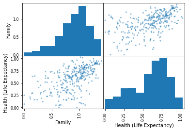

```python
scatter_matrix(df[["Family","Health (Life Expectancy)"]]);
```

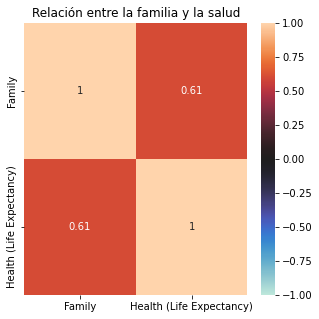

```python
# Se procede a realizar una matriz de correlacion
f,ax = plt.subplots(figsize=(5,5))
sns.heatmap(df[["Family","Health (Life Expectancy)"]].corr(method='spearman'),annot=True,vmin=-1, vmax=1, center= 0)
ax.set_title("Relación entre la familia y la salud")
plt.show()
```

### Muestra de forma gráfica la relación entre la puntuación de felicidad y la confianza (corrupción del gobierno).

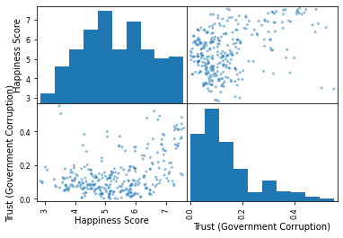

```python
# Se procede a realizar una matriz de correlacion
scatter_matrix(df[["Happiness Score","Trust (Government Corruption)"]]);
```

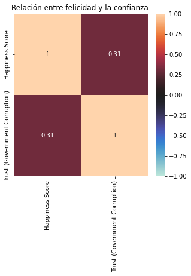

```python
f,ax = plt.subplots(figsize=(5,5))
sns.heatmap(df[["Happiness Score","Trust (Government Corruption)"]].corr(method='spearman'),annot=True,vmin=-1, vmax=1, center= 0)
ax.set_title("Relación entre felicidad y la confianza ")
plt.show()
```

### Muestra la matriz de correlación del daframe.

Se procede a realizar una matriz de correlacion, al ser muchos datos la forma en que se muestra no es la mejor o que facilite la comprensión de los datos

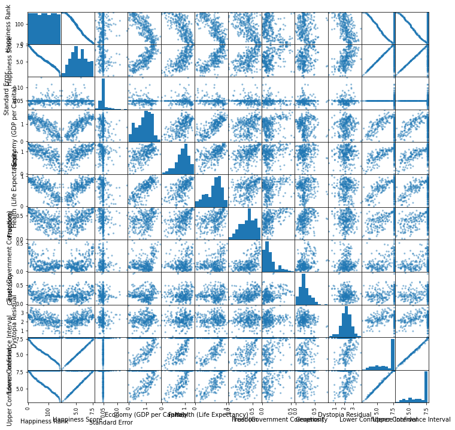

```python
scatter_matrix(df, figsize = (12, 12));
```

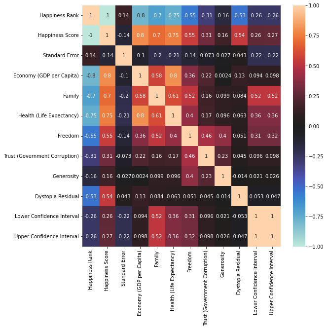

```python
f,ax = plt.subplots(figsize=(9,9))
sns.heatmap(df.corr(method='spearman'),annot=True,vmin=-1, vmax=1, center= 0)
plt.show()
```

### Tras unir los dataframes, los países aparecerán más de una vez. Muestra agrupado el dataframe por país con el valor máximo de felicidad, sin importar el año.

```python
df_pivot = df.pivot_table(index=['Country'], values=['Happiness Score'], aggfunc='max')
sort_df_pivot= df_pivot.sort_values(by=['Happiness Score'], ascending=False)
print(sort_df_pivot)
```

```
             Happiness Score
Country
Switzerland            7.587
Iceland                7.561
Denmark                7.527
Norway                 7.522
Canada                 7.427
...                      ...
Rwanda                 3.515
Benin                  3.484
Togo                   3.303
Syria                  3.069
Burundi                2.905

[164 rows x 1 columns]
```

### ¿Tiene relación la felicidad con la generosidad? Muéstralo gráficamente a través de la puntuación de libertad.

Segun los datos obtenidos no se observa una relación fuerte entre amas caracteristicas, sin embargo se procede a realizar la gráfica y motrar los datos de varias formas.

```python
relacion1 = df[['Happiness Score','Freedom','Generosity']]
relacion1.head()
```

|  | Happiness Score | Freedom | Generosity |
| --- | --- | --- | --- |
| 0 | 7.587 | 0.66557 | 0.29678 |
| 1 | 7.561 | 0.62877 | 0.43630 |
| 2 | 7.527 | 0.64938 | 0.34139 |
| 3 | 7.522 | 0.66973 | 0.34699 |
| 4 | 7.427 | 0.63297 | 0.45811 |

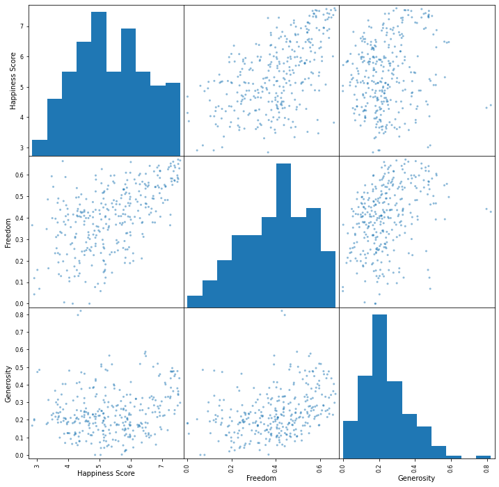

```python
scatter_matrix(relacion1, figsize = (12, 12));
```

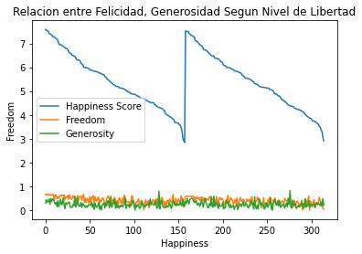

```python
plt.figure(figsize = (20,20))
relacion1.plot()
plt.title("Relacion entre Felicidad, Generosidad Segun Nivel de Libertad")
plt.ylabel("Freedom")
plt.xlabel("Happiness")
plt.show();
```

### Muestra la distribución del grado de distopía en función de la región.

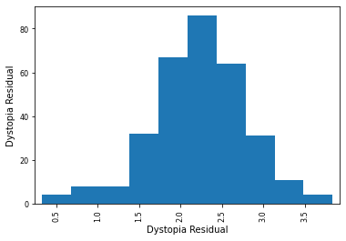

```python
scatter_matrix(df[['Dystopia Residual','Region']]);
```

```python
relacion2 = df[['Dystopia Residual','Region']]
relacion2.head()
```

|  | Dystopia Residual | Region |
| --- | --- | --- |
| 0 | 2.51738 | Western Europe |
| 1 | 2.70201 | Western Europe |
| 2 | 2.49204 | Western Europe |
| 3 | 2.46531 | Western Europe |
| 4 | 2.45176 | North America |

```python
df_pivot2 = df.pivot_table(index=['Region'], values=['Dystopia Residual'], aggfunc='mean')
sort_df_pivot2= df_pivot2.sort_values(by=['Dystopia Residual'], ascending=False)
print(sort_df_pivot2)
```

```
                                 Dystopia Residual
Region
Latin America and Caribbean               2.744404
North America                             2.598635
Australia and New Zealand                 2.388185
Western Europe                            2.268381
Central and Eastern Europe                2.145811
Middle East and Northern Africa           2.124539
Southern Asia                             2.093435
Sub-Saharan Africa                        2.091293
Southeastern Asia                         1.893965
Eastern Asia                              1.791144
```

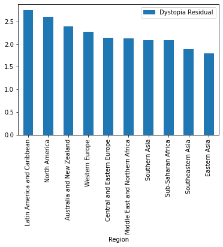

```python
sort_df_pivot2.plot(kind = 'bar')
```

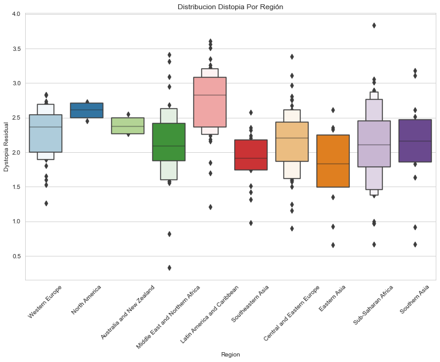

```python
sns.set_style('whitegrid')
fig, ax = plt.subplots(figsize = (12, 8))
sns.boxenplot(data = relacion2,
             x= 'Region',
             y= 'Dystopia Residual',
             palette= 'Paired')
plt.setp(ax.get_xticklabels(), rotation=45)
plt.title('Distribucion Distopia Por Región')
plt.show()
```

## Resultados

Se realiza la inspeccion de los datasets, se procede a realizar una revision de la data según lo solicitado, el dataset nos presenta la información por región y país de algunos indicadores como felicidad, confianza y libertad, por lo tanto se busca encontrar alguna relación entre los valores con algunos factores.

Se concluye que existen ciertas regiones que muestran en promedio una mayor Distopia resicual como lo son las Regiones Lationamericanas y Norte América.

Mientras que los paises que muestran mayor felicidad Suiza, Islandia y Dinamarca (todos de la region Europea).

Aquellos paises que muestran mayor nivel de felicidad tienen en comun un alto Ingreso Per capita, así como un alto indice de expectativa de vida. En mi opinión el dataset es una buena forma de poner en práctica los conocimientos en python y el análisis de datos de forma introductoria.

```python
df_pivot3 = df.pivot_table(index=['Country'], values=['Happiness Score','Health (Life Expectancy)','Economy (GDP per Capita)','Trust (Government Corruption)',], aggfunc='max')
sort_df_pivot3= df_pivot3.sort_values(by=['Happiness Score'], ascending=False)
sort_df_pivot3.head()
```

| Country | Economy (GDP per Capita) | Happiness Score | Health (Life Expectancy) | Trust (Government Corruption) |
| --- | --- | --- | --- | --- |
| Switzerland | 1.52733 | 7.587 | 0.94143 | 0.41978 |
| Iceland | 1.42666 | 7.561 | 0.94784 | 0.14975 |
| Denmark | 1.44178 | 7.527 | 0.87464 | 0.48357 |
| Norway | 1.57744 | 7.522 | 0.88521 | 0.36503 |
| Canada | 1.44015 | 7.427 | 0.90563 | 0.32957 |